# Seasonal and Harmonic Trend Modeling in Time Series

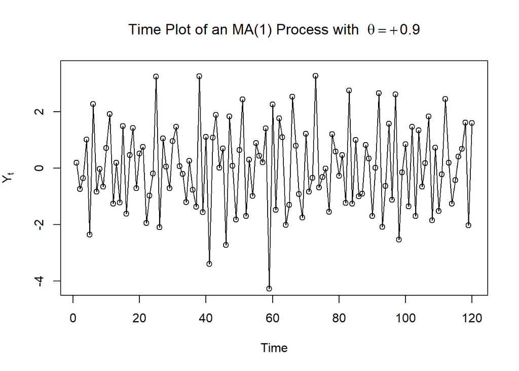

```r
data(ma1.1.s)

plot(ma1.1.s, type = "o", ylab = expression(Y[t]), xlab = "Time",
     ylim = c(-4.2, 3.5), pch = 1, cex = 1,
     main = expression("Time Plot of an MA(1) Process with " ~ theta == +0.9))
```

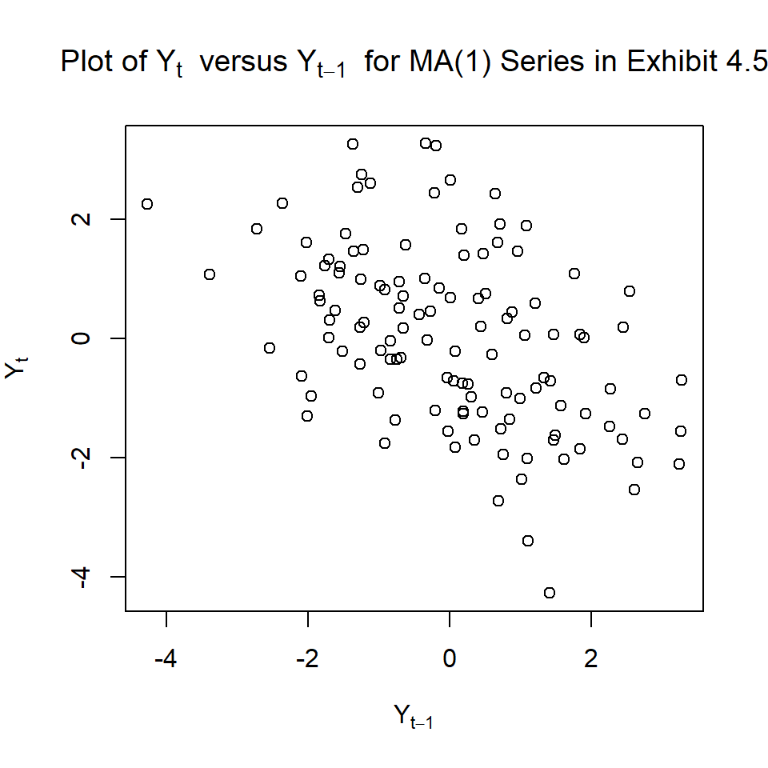

```r
data(ma1.1.s)
plot(ma1.1.s, x = zlag(ma1.1.s), ylab = expression(Y[t]),
     xlab = expression(Y[t-1]), type = 'p',
     main = expression("Plot of Y"[t] ~ " versus Y"[t-1] ~ " for MA(1) Series in Exhibit 4.5"))
```

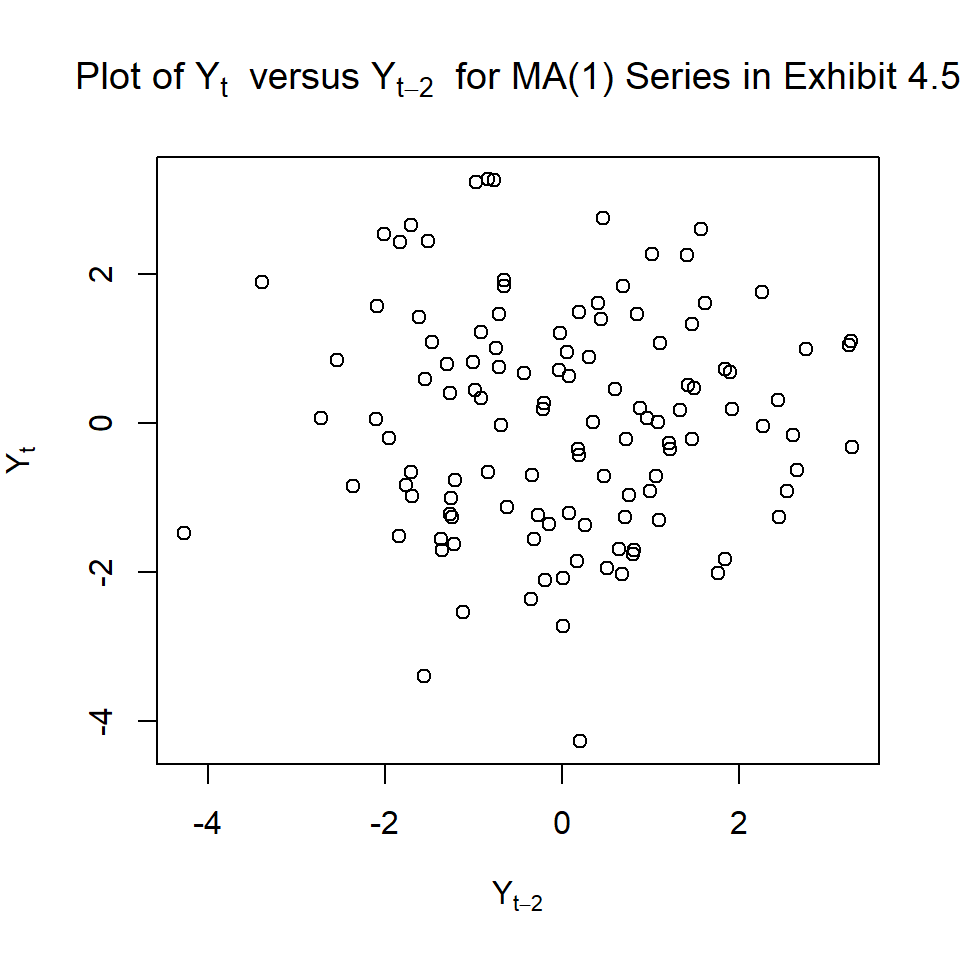

```r
data(ma1.1.s)
plot(ma1.1.s, x = zlag(ma1.1.s,2), ylab = expression(Y[t]),
     xlab = expression(Y[t-2]), type = 'p',
     main = expression("Plot of Y"[t] ~ " versus Y"[t-2] ~ " for MA(1) Series in Exhibit 4.5"))
```

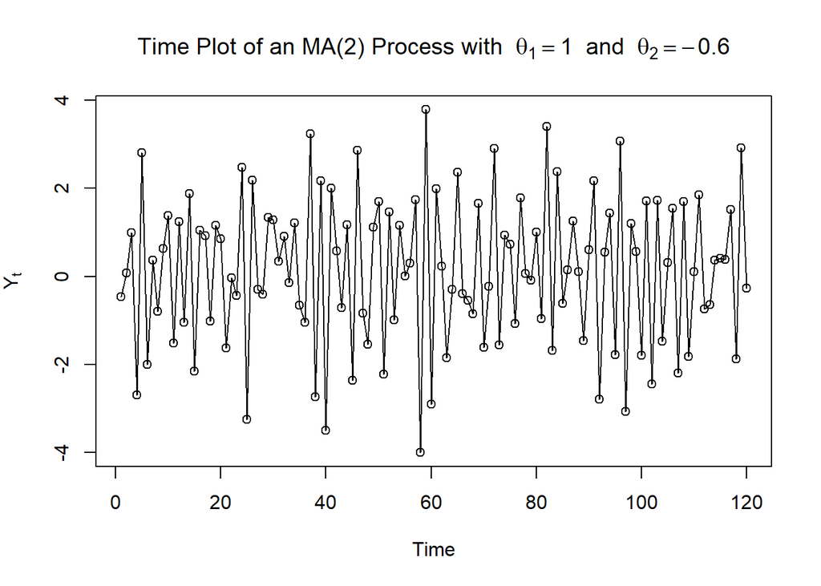

```r
data(ma2.s)
plot(ma2.s, ylab = expression(Y[t]), type = 'o',
main = expression("Time Plot of an MA(2) Process with " ~ theta[1] == 1 ~ " and " ~ theta[2] == -0.6))
```

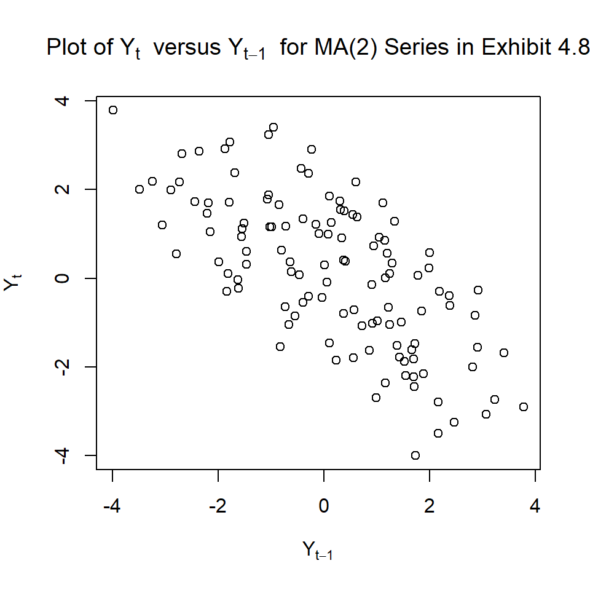

```r
data(ma2.s)
plot(ma2.s, x = zlag(ma2.s), ylab = expression(Y[t]),
     xlab = expression(Y[t-1]), type = 'p',
     main = expression("Plot of Y"[t] ~ " versus Y"[t-1] ~ " for MA(2) Series in Exhibit 4.8"))
```

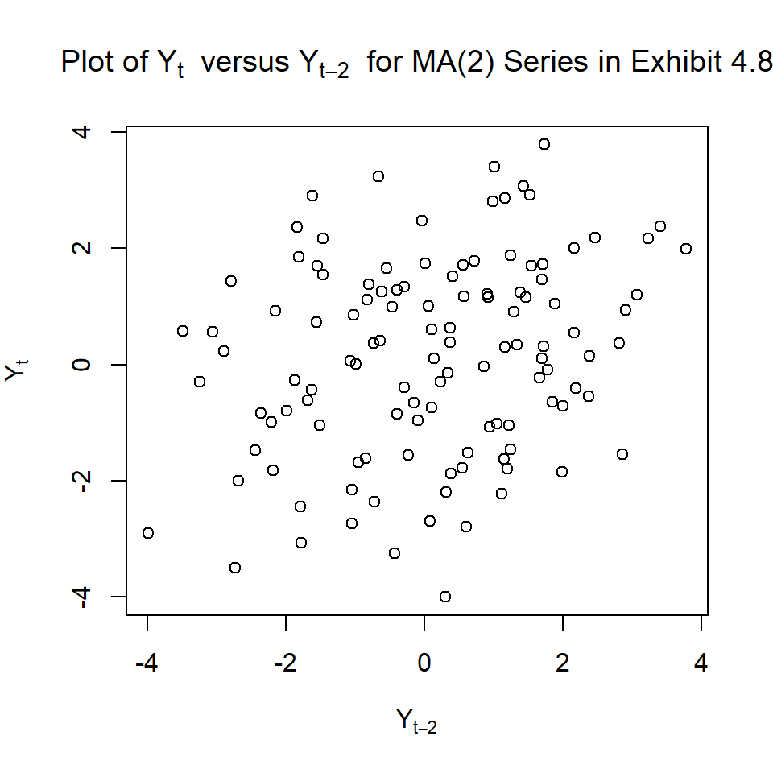

```r
data(ma2.s)
plot(ma2.s, x = zlag(ma2.s,2), ylab = expression(Y[t]),
     xlab = expression(Y[t-2]), type = 'p',
     main = expression("Plot of Y"[t] ~ " versus Y"[t-2] ~ " for MA(2) Series in Exhibit 4.8"))
```

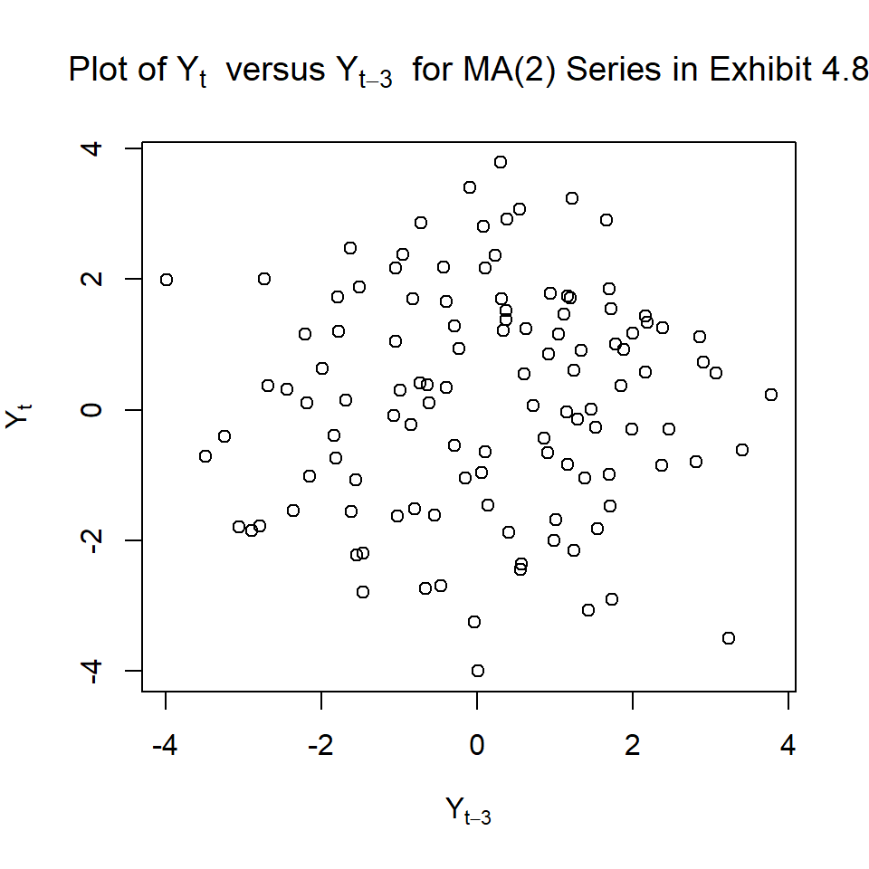

```r
data(ma2.s)
plot(ma2.s, x = zlag(ma2.s,3), ylab = expression(Y[t]),
     xlab = expression(Y[t-3]), type = 'p',
     main = expression("Plot of Y"[t] ~ " versus Y"[t-3] ~ " for MA(2) Series in Exhibit 4.8"))
```

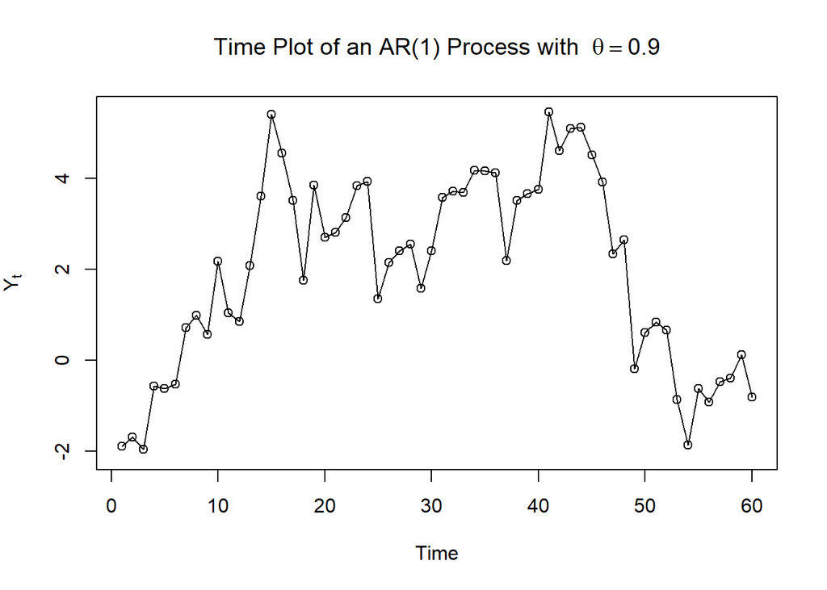

```r
data(ar1.s)

plot(ar1.s, type = "o", ylab = expression(Y[t]), xlab = "Time",
     ylim = c(-2.1, 5.5), pch = 1, cex = 1,
     main = expression("Time Plot of an AR(1) Process with " ~ theta == 0.9))
```

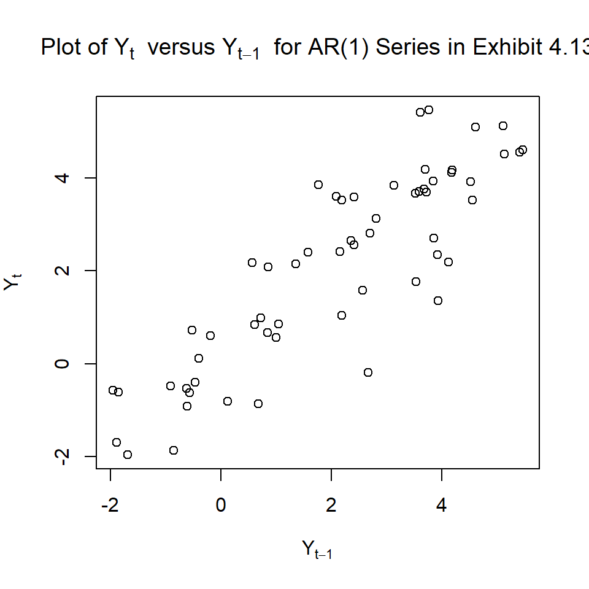

```r
plot(y = ar1.s, x = zlag(ar1.s), ylab = expression(Y[t]),
     xlab = expression(Y[t-1]), type = 'p',
     main = expression("Plot of Y"[t] ~ " versus Y"[t-1] ~ " for AR(1) Series in Exhibit 4.13"))
```

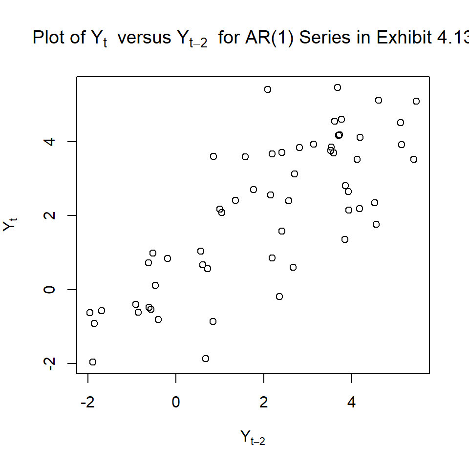

```r
plot(y = ar1.s, x = zlag(ar1.s,2), ylab = expression(Y[t]),
     xlab = expression(Y[t-2]), type = 'p',
     main = expression("Plot of Y"[t] ~ " versus Y"[t-2] ~ " for AR(1) Series in Exhibit 4.13"))
```

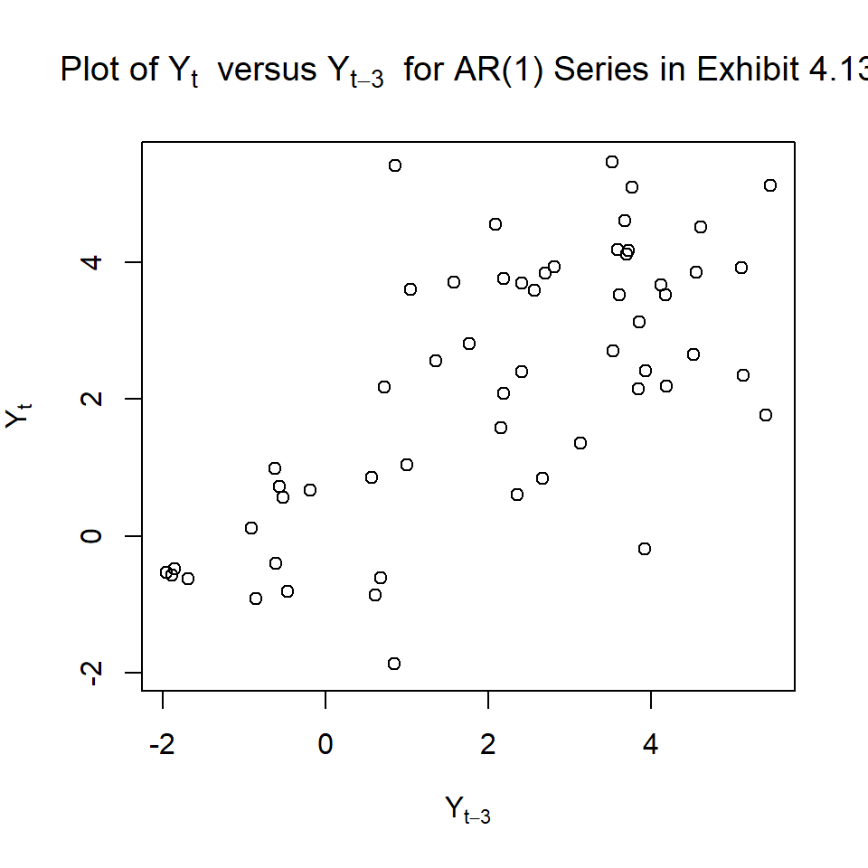

```r
plot(y = ar1.s, x = zlag(ar1.s,3), ylab = expression(Y[t]),
     xlab = expression(Y[t-3]), type = 'p',
     main = expression("Plot of Y"[t] ~ " versus Y"[t-3] ~ " for AR(1) Series in Exhibit 4.13"))
```

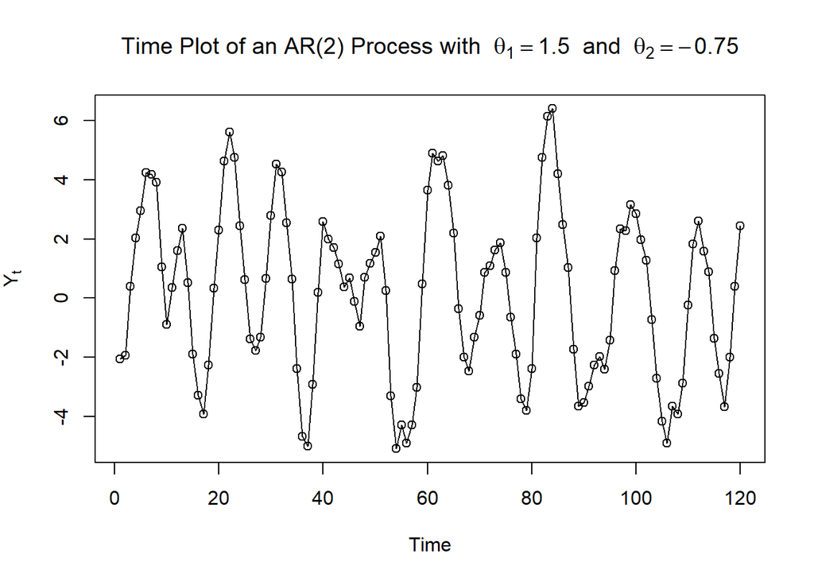

```r
data(ar2.s)
plot(ar2.s, ylab = expression(Y[t]), type = 'o',
main = expression("Time Plot of an AR(2) Process with "
                  ~ theta[1] == 1.5 ~ " and " ~ theta[2] == -0.75))
```

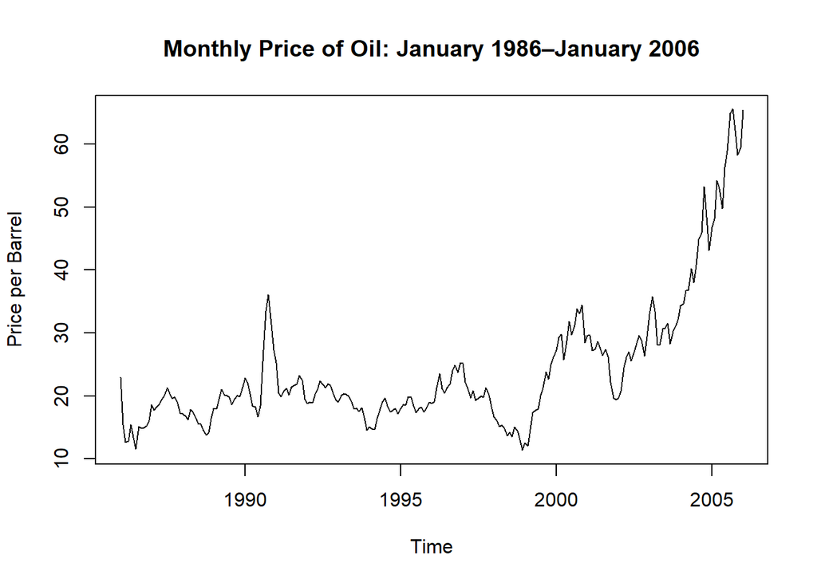

```r
data(oil.price)

plot(oil.price, ylab = "Price per Barrel", type = 'l',
     main = "Monthly Price of Oil: January 1986–January 2006")
```

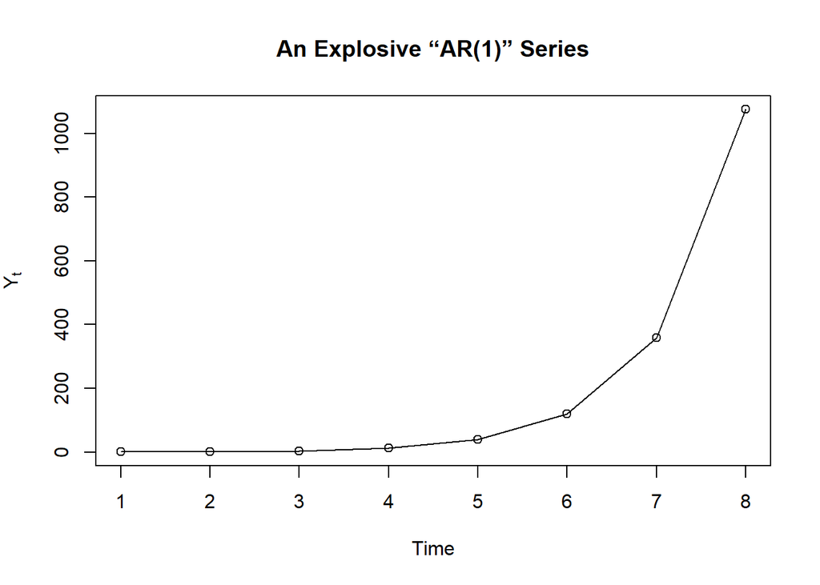

```r
data(explode.s)

plot(explode.s, ,ylab=expression(Y[t]), type = 'o',
     main = 'An Explosive “AR(1)” Series')
```

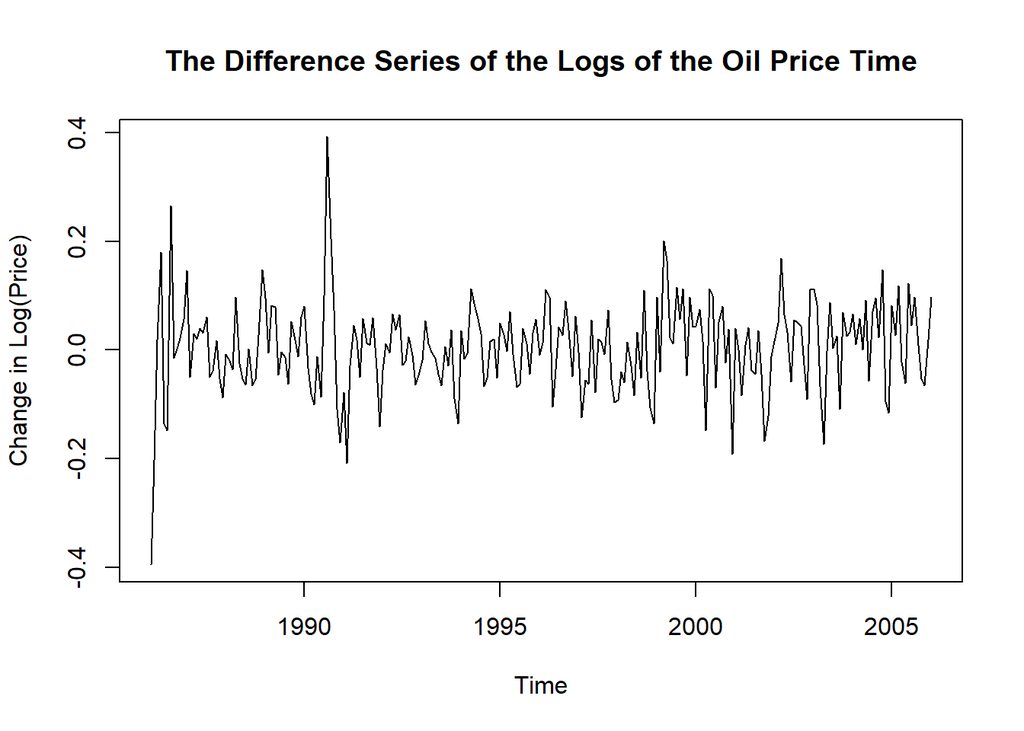

```r
data(oil.price)

 plot(diff(log(oil.price)),ylab='Change in Log(Price)',type='l',
 main = "The Difference Series of the Logs of the Oil Price Time"
)
```

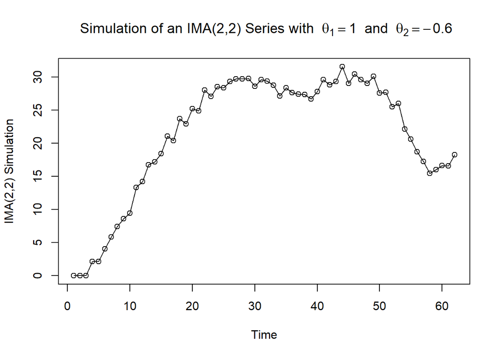

```r
data(ima22.s)

plot(ima22.s,ylab='IMA(2,2) Simulation',type='o',
main = expression(" Simulation of an IMA(2,2) Series with "
                  ~ theta[1] == 1 ~ " and " ~ theta[2] == -0.6))
```

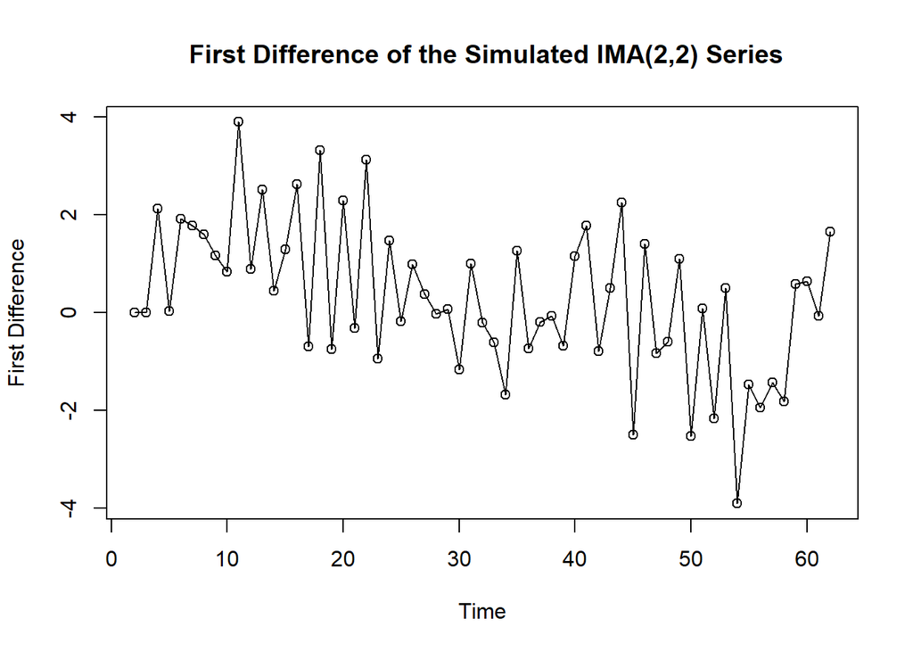

```r
data(ima22.s)

plot(diff(ima22.s),ylab='First Difference',type='o',
main = " First Difference of the Simulated IMA(2,2) Series")
```

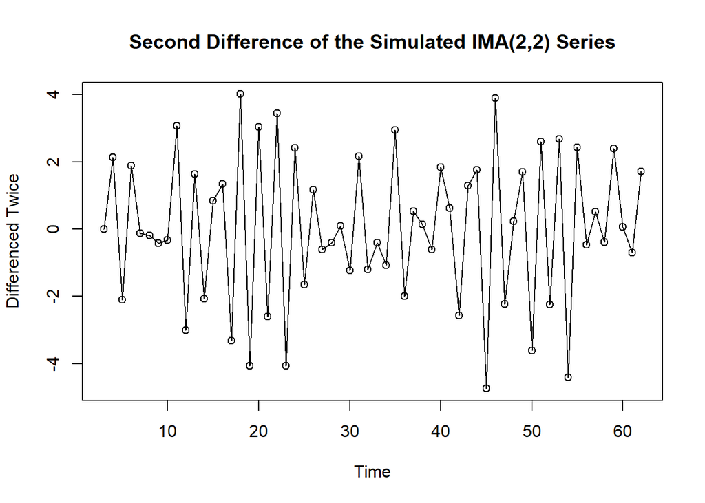

```r
data(ima22.s)

plot(diff(ima22.s,difference=2),ylab='Differenced Twice',type='o', main = "Second Difference of the Simulated IMA(2,2) Series")
```

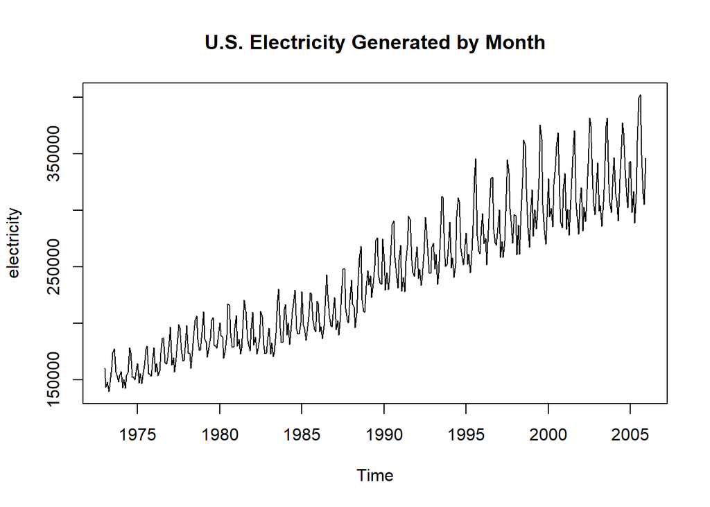

```r
data(electricity)
plot(electricity, main = "U.S. Electricity Generated by Month")
```

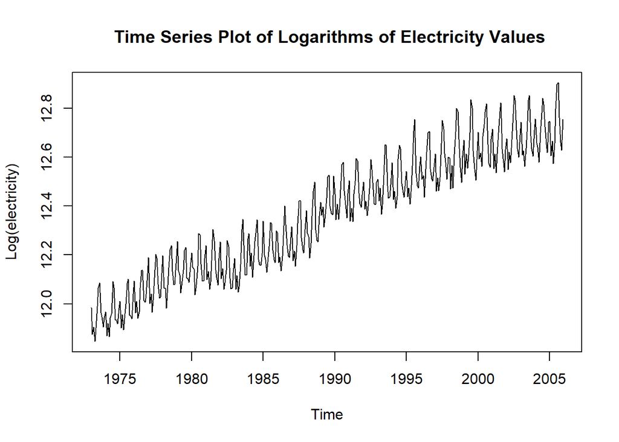

```r
data(electricity)
plot(log(electricity),ylab='Log(electricity)',
     main = " Time Series Plot of Logarithms of Electricity Values")
```

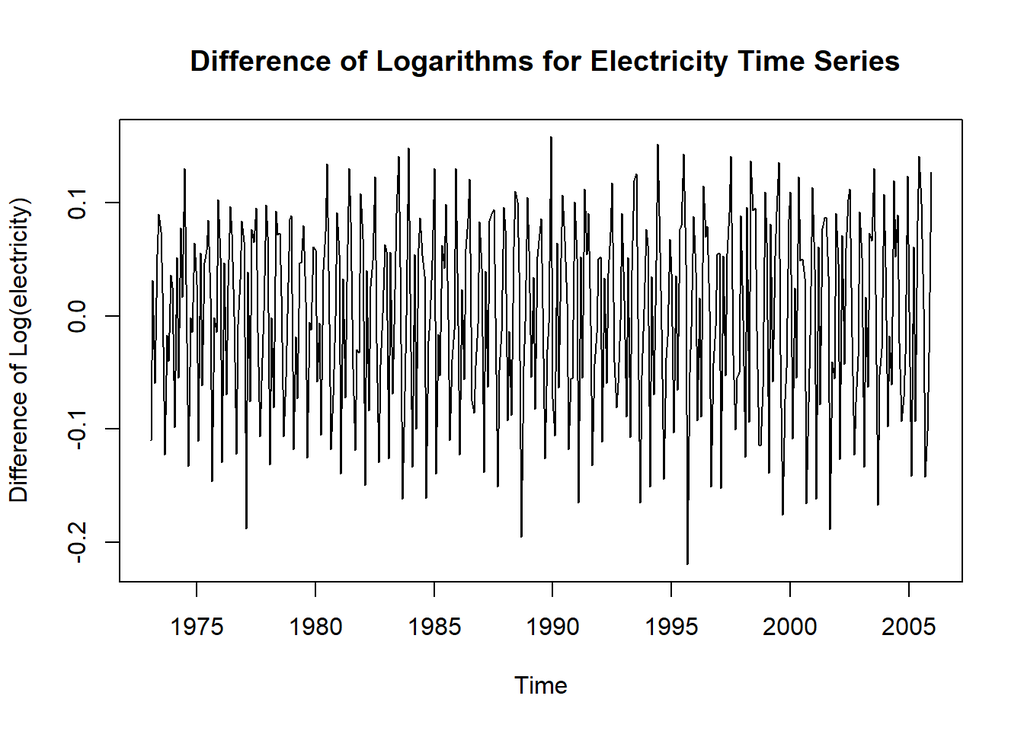

```r
data(electricity)
 plot(diff(log(electricity)), ylab='Difference of Log(electricity)',
      main = " Difference of Logarithms for Electricity Time Series")
```

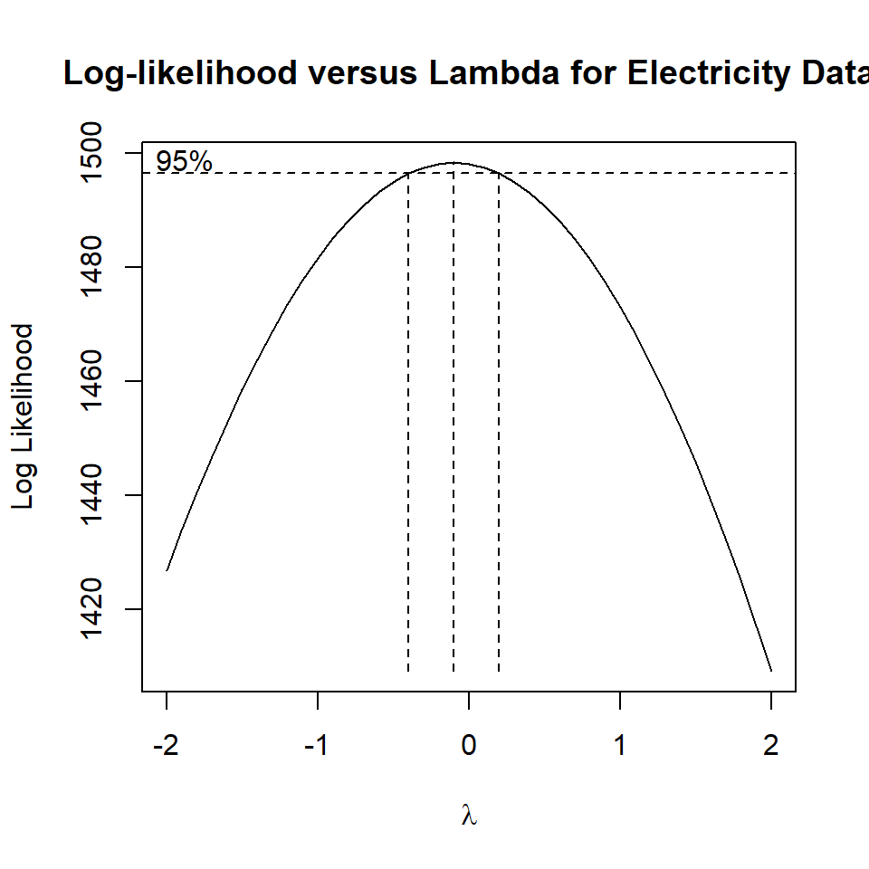

```r
data(electricity)

BoxCox.ar(electricity, plotit = TRUE)

title(main = "Log-likelihood versus Lambda for Electricity Data")
```

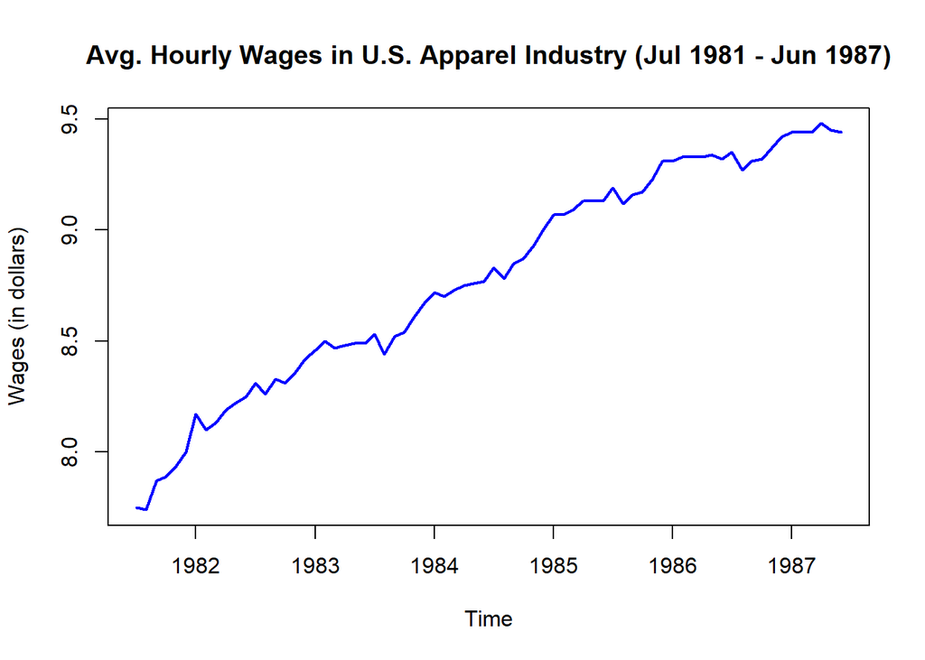

```r
data(wages)
plot(wages,
     main = "Avg. Hourly Wages in U.S. Apparel Industry (Jul 1981 - Jun 1987)",
     xlab = "Time",
     ylab = "Wages (in dollars)",
     col = "blue",
     lwd = 2)
```

```r
time <- 1:length(wages)

linear_model <- lm(wages ~ time)

summary(linear_model)
```

```
##
## Call:
## lm(formula = wages ~ time)
##
## Residuals:
##      Min       1Q   Median       3Q      Max
## -0.23828 -0.04981  0.01942  0.05845  0.13136
##
## Coefficients:
##              Estimate Std. Error t value Pr(>|t|)
## (Intercept) 7.9314358  0.0196657  403.31   <2e-16 ***
## time        0.0234234  0.0004682   50.03   <2e-16 ***
## ---
## Signif. codes:  0 '***' 0.001 '**' 0.01 '*' 0.05 '.' 0.1 ' ' 1
##
## Residual standard error: 0.08257 on 70 degrees of freedom
## Multiple R-squared:  0.9728, Adjusted R-squared:  0.9724
## F-statistic:  2503 on 1 and 70 DF,  p-value: < 2.2e-16
```

```r
linear_resid <- rstandard(linear_model)
```

Further, the Multiple and Adjusted R-squared values are 97.28% and 97.24%, respectively. This implies that the model fits the data very well.

The minimum and maximum residuals range from -0.238 to 0.131. The residuals are centered around zero; however, since the wage increase per month is 0.0234, these residuals are considerable. The Residual Standard Error is 0.08257.

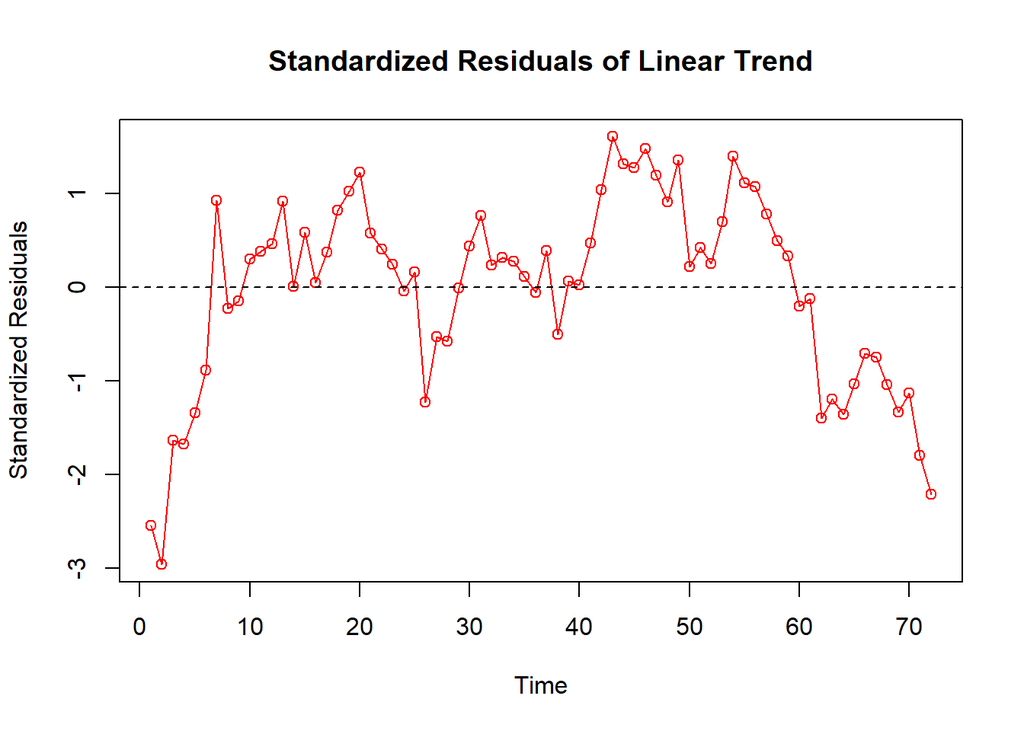

```r
plot(linear_resid, type = "o",
     main = "Standardized Residuals of Linear Trend",
     xlab = "Time", ylab = "Standardized Residuals",
     col = "red")
abline(h = 0, col = "black", lty = 2)
```

```r
time_sq <- time^2

quadratic_model <- lm(wages ~ time + time_sq)

summary(quadratic_model)
```

```
##
## Call:
## lm(formula = wages ~ time + time_sq)
##
## Residuals:
##       Min        1Q    Median        3Q       Max
## -0.148318 -0.041440  0.001563  0.050089  0.139839
##
## Coefficients:
##               Estimate Std. Error t value Pr(>|t|)
## (Intercept)  7.797e+00  2.141e-02 364.127  < 2e-16 ***
## time         3.429e-02  1.354e-03  25.328  < 2e-16 ***
## time_sq     -1.488e-04  1.797e-05  -8.282  6.1e-12 ***
## ---
## Signif. codes:  0 '***' 0.001 '**' 0.01 '*' 0.05 '.' 0.1 ' ' 1
##
## Residual standard error: 0.05889 on 69 degrees of freedom
## Multiple R-squared:  0.9864, Adjusted R-squared:  0.986
## F-statistic:  2494 on 2 and 69 DF,  p-value: < 2.2e-16
```

```r
quadratic_resid <- rstandard(quadratic_model)
```

The intercept estimates the wage at time = 0 as 7.797. The positive linear term indicates an initial monthly increase of 3.429 cents. However, the quadratic term is negative (-0.0001488). This suggests that the rate of wage increase slows over time, although wages continue to rise during the observed period. All coefficients are highly significant, and the model explains 98.64% of the variation in wages (R-squared = 0.9864). This is a noticeable increment compared to the previous linear model’s R-squared value of 0.9728. The residual standard error (0.05889) is also lower than that of the linear model (0.08257). These values provide evidence that the current model is a better fit.

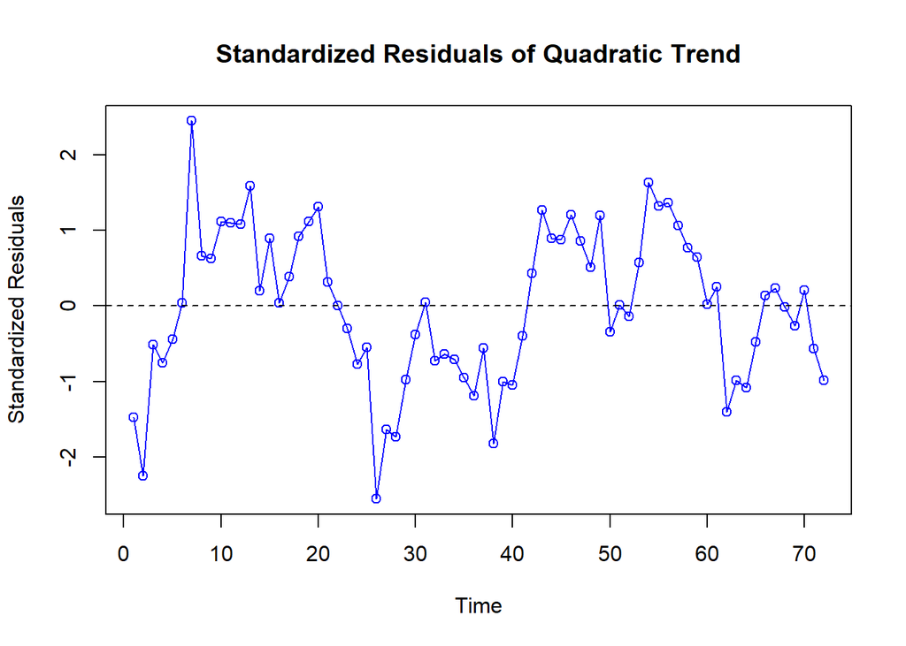

```r
plot(quadratic_resid, type = "o",
     main = "Standardized Residuals of Quadratic Trend",
     xlab = "Time", ylab = "Standardized Residuals",
     col = "blue")
abline(h = 0, col = "black", lty = 2)
```

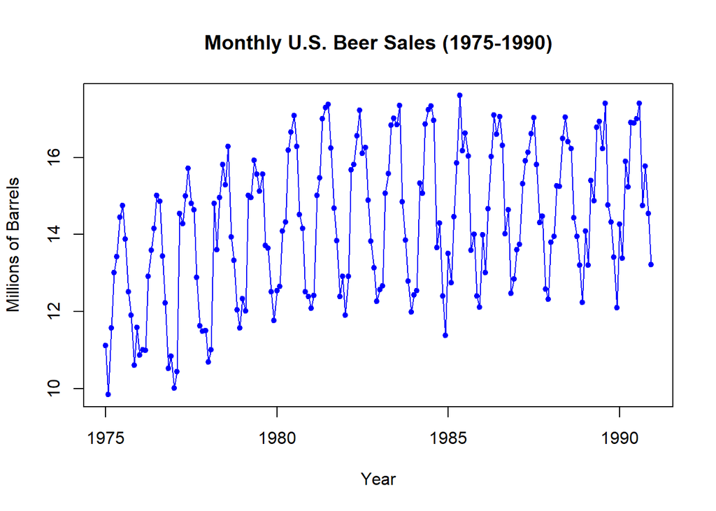

```r
data(beersales)

plot(beersales, main="Monthly U.S. Beer Sales (1975-1990)",
     ylab="Millions of Barrels", xlab="Year",
     col="blue", type="o", pch=20)
```

According to the plot, beersales exhibits a seasonal trend that has continued throughout the time period. Furthermore, if observed closely, it is evident that the same data points appear throughout the period, along with an upward trend. However, it is difficult to determine whether the same data points move in such a manner without proper labeling. Based on the plot, we can most certainly conclude that sales are seasonal.

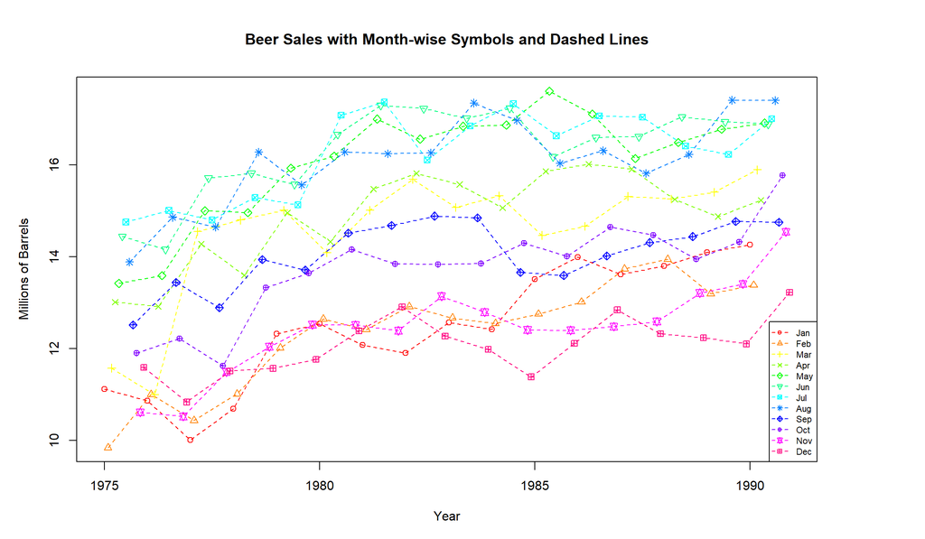

```r
par(mar=c(5, 5, 5, 7), xpd=TRUE)
months <- cycle(beersales)

plot(beersales, main="Beer Sales with Month-wise Symbols and Dashed Lines",
     ylab="Millions of Barrels", xlab="Year", type="n")

colors <- rainbow(12)

for (i in 1:12) {
  month_indices <- which(months == i)
  points(time(beersales)[month_indices], beersales[month_indices], col=colors[i], pch=i)
  lines(time(beersales)[month_indices], beersales[month_indices], col=colors[i], lty=2)
}

legend("bottomright", legend=month.abb, col=colors, pch=1:12, lty=2, cex=0.7)
```

The new plot provides more information. We can now see how sales vary by month. Beer is a popular drink that comes in various brands, manufactured by different entities. Beer consumption increases in the summer, as a cold beer can be refreshing in hot weather. If we follow the lines from May through August, they consistently show the highest sales, which is reasonable because this period corresponds to summertime. Conversely, sales are lower from November through February, which makes sense as this period corresponds to the fall and winter seasons.